# Lab#02 - Worksheet01172017_EP

## Lab Worksheet #02

This notebook does not need to be submitted. This is only for you to gain experience and get some practice.

## boolean type

True, False

```python
True
```

```
True
```

```python
False
```

```
False
```

## Making boolean statements

$ >, >=, ==, !=, <=, < $

```python
4**4 > 15**2
```

```
True
```

```python
9*7*5*3*1 <= 10*8*6*4*2
```

```
True
```

```python
2**10 != 1024
```

```
False
```

## Combining boolean statements

not (negates your statement)

and (checks if both statements are true)

or (checks if at least one statement is true)

```python
not True
```

```
False
```

```python
True and (not False)
```

```
True
```

```python
True and (not True)
```

```
False
```

```python
True or (not True)
```

```
True
```

```python
False or False
```

```
False
```

```python
(2**10 >= 1024) or (not (9*7*5*3*1 <= 10*8*6*4*2))
```

```
True
```

## Refresher: Creating variables and defining functions.

### 1. Create a variable named x containing the value 10.

```python
# Complete the Example here.
x = 10
```

### 2. Write a function mycubed(x) returning $x^3$.

```python
# Complete the Example here.
def mycubed(x):
    return x**3

#def mycubedC(x):
#    return x^3 don't use ^ for exponentiation!

mycubed(3)
#mycubedC(3)
```

```
27
```

## Forming if, if-else, if-elif-else statements

### if statements

if statement 1:

```
code to evaluate if statement 1 is True.
```

#### Example: Write a function isnegative(y) that returns True if $y$ is a negative number.

```python
# Complete the Example here.
def isnegative(y):
    if y < 0:
        return True
```

```python
isnegative(-3) # Should return True.
```

```
True
```

```python
isnegative(3) # Should return nothing at all. Do you know why?
```

### if-else statements

if statement 1:

```
code to evaluate if statement 1 is True.
```

else:

```
code to evaluate if statement 1 is not True.
```

#### Example: Write a function isnonnegative(y) that returns True if y is non-negative and False otherwise.

```python
# Complete the Example here.
def isnonnegative(y):
    if y >= 0:
        return True
    else:
        return False
```

```python
isnonnegative(-3) # Should return False.
```

```
False
```

```python
isnonnegative(0) # Should return True.
```

```
True
```

```python
isnonnegative(3) # Should return True.
```

```
True
```

### if-elif-else statements

if statement 1:

```
code to evaluate if statement 1 is True.
```

elif statement 2: #elif stands for elseif in short

```
code to evaluate if statement 1 is not True,
but if statement 2 is True.
```

else:

```
code to evaluate if both statement 1 and statement 2 not True.
```

#### Example: Write a function myspecialF(y,z) that returns $\left\vert y-z\right\vert$ if $\left\vert y-z\right\vert$ >= 1, elseif returns $\frac{\left\vert y-z\right\vert}{2}$ if $\left\vert y-z\right\vert$ is between 0 and 1, else returns 0.0 otherwise. Note: The abs(x) function is not part of the math module. We can use it directly.

```python
# Complete the Example here.
def myspecialF(y,z):
    if abs(y-z)>=1 :
        return abs(y-z)
    # elif abs(y-z)>0 and abs(y-z)<1 :
    #    return abs(y-z)/2
    # matlab won't work if you do this...
    elif 0<abs(y-z)<1:
        return abs(y-z)/2
    else:
        return 0.0
```

```python
myspecialF(-11,-11.5) # Should return 0.25.
```

```
0.25
```

```python
myspecialF(12,5) # Should return 7.
```

```
7
```

```python
myspecialF(5,12) # Should return 7.
```

```
7
```

```python
myspecialF(90,90) # Should return 0.0.
```

```
0.0
```

## Import libhw01.py from homework 1.

```python
import libhw01
# To import libhw01, you need to make sure this file is in the same folder as LabWorksheet01162017.ipynb.
```

## Plot myspecialF(y,z) using drawfunction from libhw01.

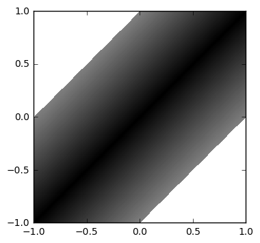

```python
# Note libhw01 is already imported. Don't have to import again within the same notebook.
libhw01.drawfunction(myspecialF)
```

### Exercise 1: Make a function called myEx1(y,z) that returns 1.0 if the point (y,z) is in a disk of radius 0.5 centered at the origin and returns 0.0 otherwise. Use the drawfunction function from libhw01 to check your results.

```python
# Complete Exercise 1 here.
# circle x**2 + y**2 = r**2 ,(boundary)
# disk x**2 + y**2 < r**2 ,(interior)
def myEx1(y,z):
    r = 0.5
    if (y-0)**2 + (z-0)**2 < r**2:
        return 1.0
    else:
        return 0.0
```

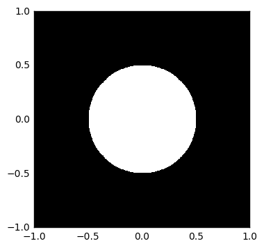

```python
# Note libhw01 is already imported. Don't have to import again within the same notebook.
libhw01.drawfunction(myEx1)
```

### Exercise 2: Make a function called myEx2(y,z) that returns 1.0 if the point (y,z) is in one of three disks centered at (-0.5,-0.5), origin, (0.5,0.5) with radius 0.1 and returns 0.0 otherwise. Use the drawfunction function from libhw01 to check your results.

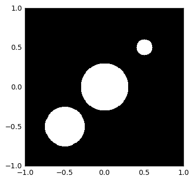

```python
# Complete Exercise 2 here.
def myEx2(y,z):
    r1 = 0.3
    r2 = .1
    r3 = .25
    # Solution is modified so each circle can have a different radius.
    if (y-0)**2 + (z-0)**2 < r1**2 or (y-0.5)**2 + (z-0.5)**2 < r2**2 or (y-(-0.5))**2 + (z-(-0.5))**2 < r3**2:
        return 1.0
    else:
        return 0.0

libhw01.drawfunction(myEx2)
```

[figure not shown]

```python
# Note libhw01 is already imported. Don't have to import again within the same notebook.
libhw01.drawfunction(myEx2)
```